# Ethogram Data Collection 1 - Working (Success, Fail)

Marinara Marcato

# 1 Introduction

This document shows the data analysis carried out to investigate the association between ethogram scores filled out by two trainers and the dog’s working outcome. Statistical methods will be used to test the hypothesis that there is a relationship between ethogram scores at DC1 and working outcome (Success, Fail).

# 2 Data Exploration

The dataset comprised of the following types and number of variables. The original ethogram items contained ordinal and categorical variables. The score variables were numerical derived from the original ethogram items.

```
##
## categorical    comments        info     ordinal       score        time
##          17          16          17          53          42          25
##      unused
##          11
```

```
## [1] 17
```

All ordinal (N = 53) and categorical (N = 17) variables from the original ethogram items, score (N = 42) variables derived from the original ethogram items and demographical variables (N = 2) - namely, Sex and Breed - will be analysed.

## 2.1 Demographics

```
## Original dataset (dogs, variables):  58 132
```

```
##
##        GR GRxPoodle        LR       LRx     LRxGR
##         1         0        25         9        23
```

```
##
## Other    LR LRxGR
##     1    25    32
```

```
## Final dataset (dogs, variables):  58 132
```

```
##
## Success    Fail
##      46      12
```

```
##
##   Success      Fail
## 0.7931034 0.2068966
```

```
## [1] "Dogs who failed after completing the training programme while on the working programmes"
```

```
##     Name
## 1 Herbie
```

```
##
##  F  M
## 30 28
```

Calculate descriptive statistics for age at arrival at the training centre for formal training. Calculate descriptive statistics for age at assessment when the dogs performed the behaviour test at data collection 1, which should be around week 3 of formal training.

```
## Age at Arrival: Mean 15.26 Standard Deviation 1.9 Minimum: 12.59 Maximum: 21.9
```

```
## Age at Assessment: Mean 16.11 Standard Deviation 1.86 Minimum: 13.45 Maximum: 22.62
```

Calculate statistics of duration of training for the dogs that were withdrawn from training. Performing this behaviour test at the beginning on the training (Week 3) would allow assistance dog training organisations to understand which dog are more suitable and allow them to make informed decisions when analysing which dogs to keep for training considering the results of this objective assessment.

```
## [1] "Duration of Training in weeks"
```

```
##     Duration
##  Min.   : 8.857
##  1st Qu.:13.964
##  Median :16.286
##  Mean   :18.143
##  3rd Qu.:18.643
##  Max.   :36.000
```

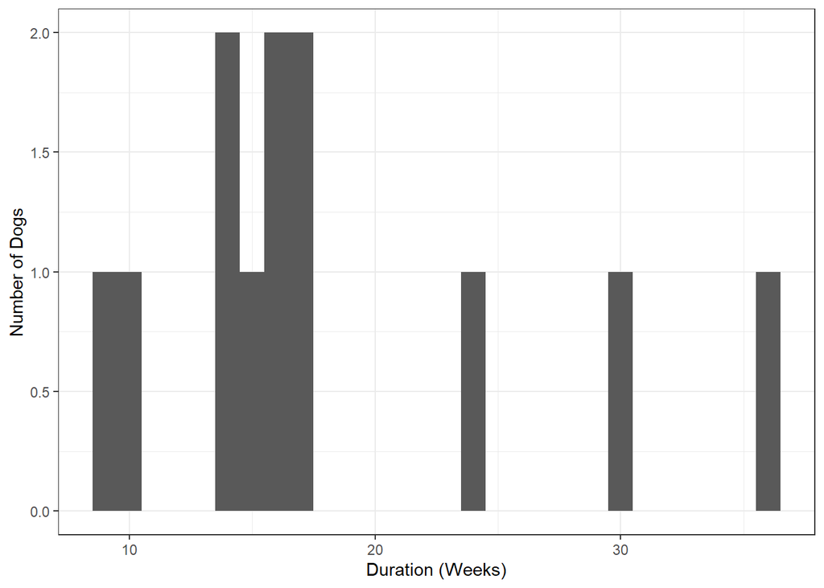

## 2.2 Descriptive Statistics

Calculate descriptive statistics for numerical and categorical variables.

```
##                                                      Min.   X1st.Qu.     Median
## Data.Collection.Number                           1.000000   1.000000   1.000000
## Duration                                        62.000000 142.000000 215.000000
## Familiarisation.Response..Oriented.to.Handler.   1.000000   1.000000   2.000000
## Familiarisation.Response..Exploration.           1.000000   4.000000   5.000000
## Familiarisation.Response..Waiting.               1.000000   1.000000   1.000000
## Call.Back.Response                               1.000000   1.000000   1.000000
## Walking.Distractibility                          1.000000   1.000000   2.000000
## Walking.Pull.on.leash                            1.000000   1.000000   1.000000
## Walking.Pull.strength                            1.000000   1.000000   1.000000
## Walking.Initiative                               1.000000   2.000000   2.000000
## Standing.Response                                1.000000   2.000000   2.000000
## Sitting.Response                                 1.000000   1.000000   2.000000
## Lying.Response                                   1.000000   1.250000   3.000000
## Lying.Settled                                    1.000000   1.000000   2.000000
## Body.check.Table                                 1.000000   3.000000   4.000000
## Body.check.Response                              1.000000   3.000000   3.000000
## Distractions.First.Response..Teddy.              1.000000   3.000000   4.000000
## Distractions.First.Response..Human.              2.000000   3.000000   3.000000
## Distractions.First.Response..Car.                1.000000   3.000000   3.000000
## Distractions.First.Response..Food.               1.000000   3.000000   4.000000
## Distractions.Second.Response..Teddy.             1.000000   2.000000   3.000000
## Distractions.Second.Response..Human.             1.000000   2.000000   3.000000
## Distractions.Second.Response..Car.               1.000000   2.000000   3.000000
## Distractions.Second.Response..Food.              1.000000   3.000000   4.000000
## Distractions.Pull.on.leash                       1.000000   2.000000   3.000000
## Distractions.Pull.strength                       1.000000   2.250000   3.000000
## Distractions.Human                               3.000000   4.000000   5.000000
## Kong.Presentation.Response                       2.000000   2.500000   4.000000
## Kong.Interaction.Response.to.stimulus            2.000000   3.000000   3.000000
## Kong.Interaction.Response.to.handler             1.000000   1.000000   1.000000
## Kong.Interaction.Back                            1.000000   1.000000   1.000000
## Kong.Return.Handler                              1.000000   2.000000   2.000000
## Dog.Response                                     1.000000   4.000000   5.000000
## Dog.Call.Back.Response                           1.000000   1.000000   2.000000
## Crate.Entering                                   1.000000   1.000000   1.000000
## Crate.Behaviours..Settled.                       1.000000   1.000000   2.000000
## Crate.Behaviours..Sniffing.Exploring..           1.000000   2.000000   2.000000
## Crate.Behaviours..Actively.Seeking.Attention.    1.000000   1.000000   2.000000
## Crate.Behaviours..Digging.                       1.000000   1.000000   1.000000
```

[output cut: 242 more lines]

```
## S.Crate.Stimulus_mean                            2.500000    1
## S.Crate.Stimulus_prod                           27.000000    0
## S.Crate.Handler_mean                             4.000000    1
## S.Crate.Handler_prod                            60.000000    0
## S.Petting.Stimulus.During_mean                   4.000000    1
## S.Petting.Stimulus.During_prod                  15.000000    0
## S.Petting.Engagement.During_mean                 3.500000    1
## S.Petting.Engagement.During_prod                10.000000    0
## S.Petting.After_mean                             3.500000    1
## S.Petting.After_prod                            12.000000    0
## S.Isolation.Handler_mean                         4.000000    0
## S.Isolation.Handler_prod                        60.000000    0
## S.Isolation.Stimulus                             3.000000    0
## S.Sociability_mean                               5.333333    0
## S.Sociability_prod                             150.000000    0
```

[output not shown]

## 2.3 Validity

Categorical: 1 out of 17 ethogram items, 1 out of 2 demographics variables (Sex and Breed).

```
## Categorical variable with 3 factors: Other LR LRxGR
```

```
##
## Call:
## glm(formula = Working ~ x, family = binomial(link = logit), data = dc_cat,
##     na.action = na.exclude)
##
## Deviance Residuals:
##     Min       1Q   Median       3Q      Max
## -0.6681  -0.6681  -0.6444  -0.6444   1.8297
##
## Coefficients:
##             Estimate Std. Error z value Pr(>|z|)
## (Intercept)    16.57    2399.54   0.007    0.994
## xLR           -17.95    2399.54  -0.007    0.994
## xLRxGR        -18.03    2399.54  -0.008    0.994
##
## (Dispersion parameter for binomial family taken to be 1)
##
##     Null deviance: 59.139  on 57  degrees of freedom
## Residual deviance: 55.905  on 55  degrees of freedom
## AIC: 61.905
##
## Number of Fisher Scoring iterations: 15
```

```
## Categorical variable with 4 factors: Both Left None Righ
```

```
##
## Call:
## glm(formula = Working ~ x, family = binomial(link = logit), data = dc_cat,
##     na.action = na.exclude)
##
## Deviance Residuals:
##     Min       1Q   Median       3Q      Max
## -0.9005  -0.7585  -0.3124  -0.3124   2.4676
##
## Coefficients:
##               Estimate Std. Error z value Pr(>|z|)
## (Intercept) -1.099e+00  8.165e-01  -1.346    0.178
## xLeft        4.055e-01  1.021e+00   0.397    0.691
## xNone       -1.897e+00  1.310e+00  -1.448    0.148
## xRigh        9.362e-16  1.054e+00   0.000    1.000
##
## (Dispersion parameter for binomial family taken to be 1)
##
##     Null deviance: 51.336  on 52  degrees of freedom
## Residual deviance: 45.810  on 49  degrees of freedom
##   (5 observations deleted due to missingness)
## AIC: 53.81
##
## Number of Fisher Scoring iterations: 5
```

Ordinal: 7 out of 53 ethogram items. Score: 10 out of 42 variables.

Save results from univariate analysis.

Converting logistic regression result to odds ratio and confidence intervals.

## 2.4 Feature Selection

Metholodogy adapted from Hosmer2013, pg 107 (GLOW study example).

### 2.4.1 Step 1: Univariate logistic regression model results.

**Variables with p < 0.25 (N = 28): original (N = 13), scores (N = 15) some are repeated**, **after removing related variables (N = 13): original (N = 9), scores (N = 4)**.

Variables whose logistic regression model resulted in p<0.15 when used to predict Working are shown. Positive estimates increase the probability of failure, while negative estimates decrease the probability of failure.

```
##                                                p_value_1
## Familiarisation.Response..Oriented.to.Handler.    0.0408
## Familiarisation.Response..Exploration.            0.0096
## Walking.Initiative                                0.1418
## Distractions.Pull.on.leash                        0.0712
## Crate.Behaviours..Sniffing.Exploring..            0.0012
## Crate.Behaviours..Actively.Seeking.Attention.     0.0369
## S.Familiarisation.Handler_mean                    0.0645
## S.Distractions.Pull_mean                          0.0394
## S.Distractions.Pull_prod                          0.0451
## S.Walking.Distractions.Pull_prod                  0.0538
## S.Distractions.Difference_mean                    0.1009
## S.Crate.Stimulus_mean                             0.0502
## S.Crate.Handler_mean                              0.0684
## S.Crate.Handler_prod                              0.1321
## S.Isolation.Handler_prod                          0.1337
```

```
##                                                p_value Significance
## Familiarisation.Response..Oriented.to.Handler.  0.0408          ***
## Familiarisation.Response..Exploration.          0.0096          ***
## Walking.Initiative                              0.1418            *
## Distractions.Pull.on.leash                      0.0712           **
## Crate.Behaviours..Sniffing.Exploring..          0.0012          ***
## Crate.Behaviours..Actively.Seeking.Attention.   0.0369          ***
## S.Familiarisation.Handler_mean                  0.0645           **
## S.Distractions.Pull_mean                        0.0394          ***
## S.Distractions.Pull_prod                        0.0451          ***
## S.Walking.Distractions.Pull_prod                0.0538           **
## S.Distractions.Difference_mean                  0.1009            *
## S.Crate.Stimulus_mean                           0.0502           **
## S.Crate.Handler_mean                            0.0684           **
## S.Crate.Handler_prod                            0.1321            *
## S.Isolation.Handler_prod                        0.1337            *
```

### 2.4.2 Step 2: Correlation

```
## [1] "S.Distractions.Pull_mean" "S.Crate.Handler_mean"
```

[figure not shown]

## 2.5 Missing Data

DC1, missing values per column and per row. Very few data are missing considering the original items selected.

```
##                        Working S.Familiarisation.Handler_mean
##                              0                              1
##             Walking.Initiative       S.Distractions.Pull_mean
##                              0                              0
## S.Distractions.Difference_mean          S.Crate.Stimulus_mean
##                              0                              1
##           S.Crate.Handler_mean
##                              1
```

```
## dc_row_nas
##  0  1  2
## 56  1  1
```

## 2.6 Visualization

```
## Plot these features manually:
```

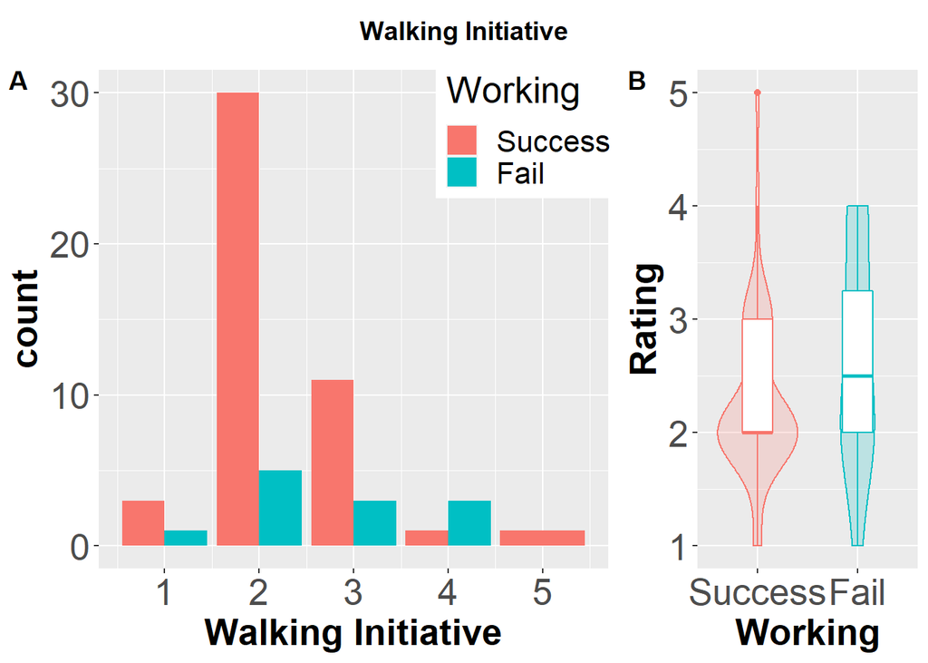

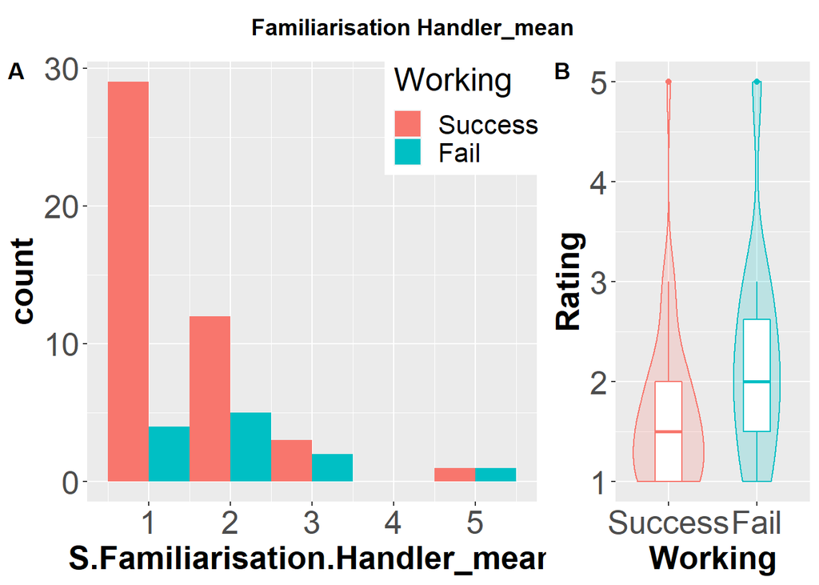

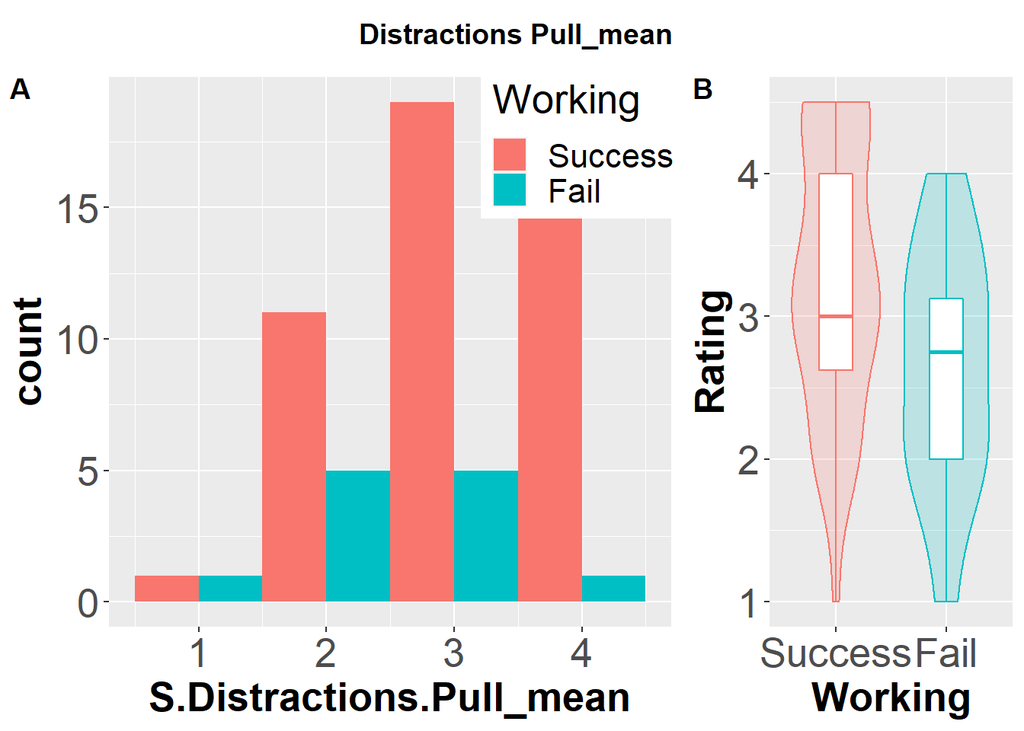

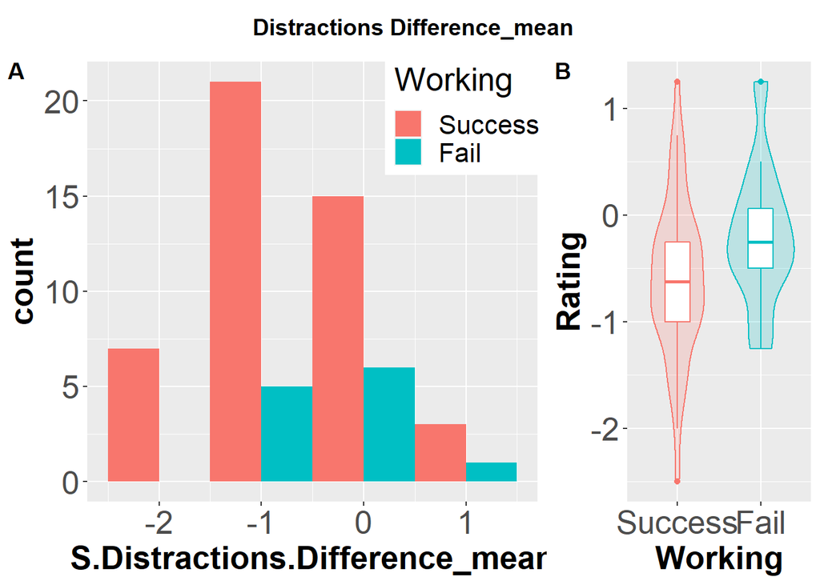

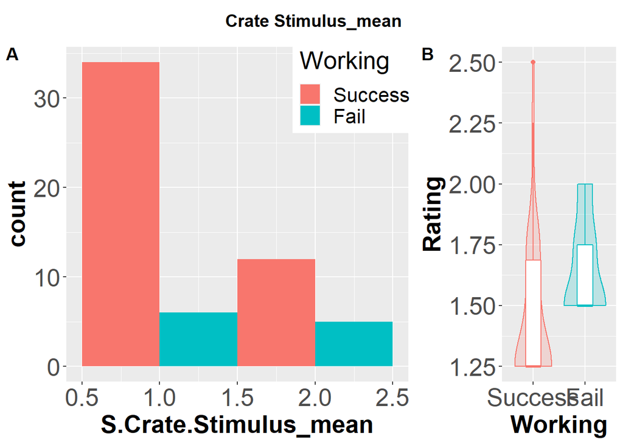

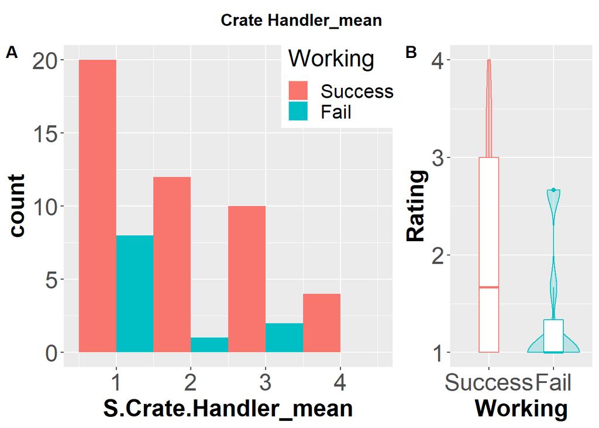

# 3 Multivariate Model

Preprocessing: Normalization + Imputation. Recursive Feature Elimination (RFE) + Multivariate Logistic Regression (LR). Optimising for F, sometimes recall, sometimes precision. Build model.

```
## [1] "Working"                        "S.Familiarisation.Handler_mean"
## [3] "Walking.Initiative"             "S.Distractions.Pull_mean"
## [5] "S.Distractions.Difference_mean" "S.Crate.Stimulus_mean"
## [7] "S.Crate.Handler_mean"
```

```
## predicting second class: Fail Success
```

```
##
## Recursive feature selection
##
## Outer resampling method: Cross-Validated (58 fold)
##
## Resampling performance over subset size:
##
##  Variables AUC Precision Recall   F AUCSD PrecisionSD RecallSD FSD
##          1 NaN    0.0000 0.0000 NaN    NA      0.0000   0.0000  NA
##          2 NaN    0.0000 0.0000 NaN    NA      0.0000   0.0000  NA
##          3 NaN    0.2222 0.1667   1    NA      0.4410   0.3892   0
##          4 NaN    0.3333 0.2500   1    NA      0.5000   0.4523   0
##          5 NaN    0.2727 0.2500   1    NA      0.4671   0.4523   0
##          6 NaN    0.5455 0.5000   1    NA      0.5222   0.5222   0
##  Num_Resamples Selected
##             58
##             58
##             58
##             58
##             58
##             58        *
##
## The top 5 variables (out of 6):
##    S.Crate.Stimulus_mean, S.Crate.Handler_mean, S.Familiarisation.Handler_mean, Walking.Initiative, S.Distractions.Difference_mean
```

```
##
## Call:
## glm(formula = Class ~ ., family = "binomial", data = tmp)
##
## Deviance Residuals:
##      Min        1Q    Median        3Q       Max
## -2.57437   0.05132   0.25749   0.53046   1.30873
##
## Coefficients:
##                                Estimate Std. Error z value Pr(>|z|)
## (Intercept)                      2.3986     0.6723   3.567  0.00036 ***
## S.Crate.Stimulus_mean           -1.2842     0.5220  -2.460  0.01388 *
## S.Crate.Handler_mean             1.0872     0.5686   1.912  0.05589 .
## S.Familiarisation.Handler_mean  -0.5996     0.3467  -1.730  0.08370 .
## Walking.Initiative              -0.5228     0.4510  -1.159  0.24636
## S.Distractions.Difference_mean  -0.4845     0.4405  -1.100  0.27130
## S.Distractions.Pull_mean         0.4171     0.4509   0.925  0.35494
## ---
## Signif. codes:  0 '***' 0.001 '**' 0.01 '*' 0.05 '.' 0.1 ' ' 1
##
## (Dispersion parameter for binomial family taken to be 1)
##
##     Null deviance: 59.139  on 57  degrees of freedom
## Residual deviance: 39.834  on 51  degrees of freedom
## AIC: 53.834
##
## Number of Fisher Scoring iterations: 6
```

Model fitness with deviance analysis.

```
##
## deviance difference:  19.30456
```

```
##
## df difference:  6
```

```
##
## level of significance:  0.003679038
```

```
##
## the model is a good fit:  TRUE
```

## 3.1 Performance

Performance metrics ROC and PR curves.

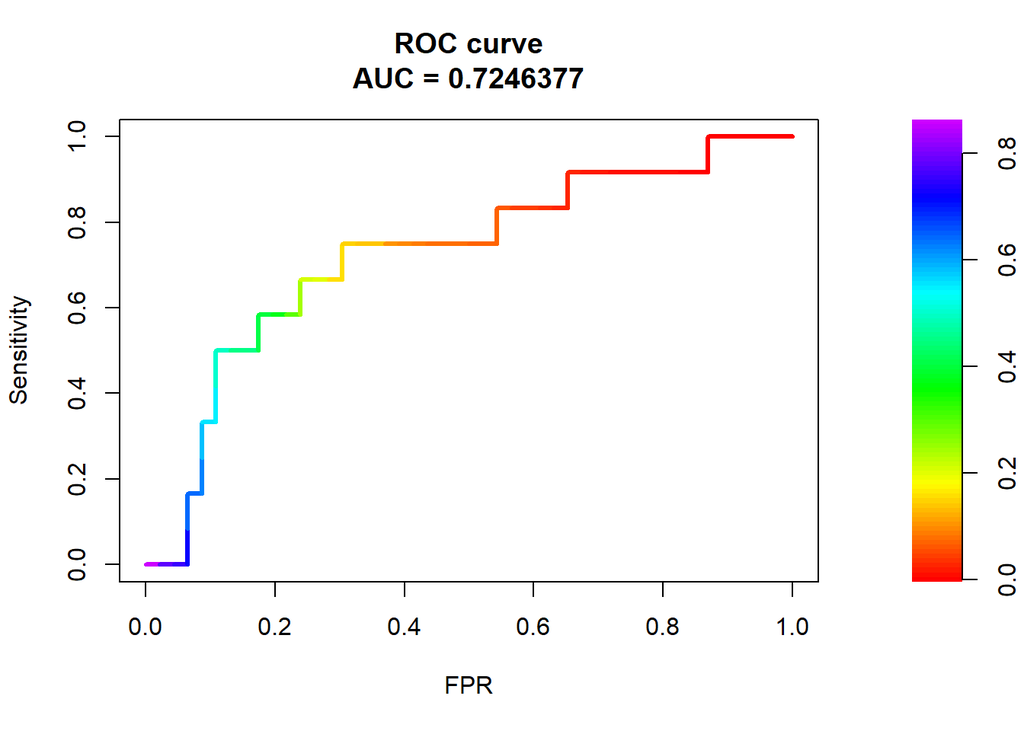

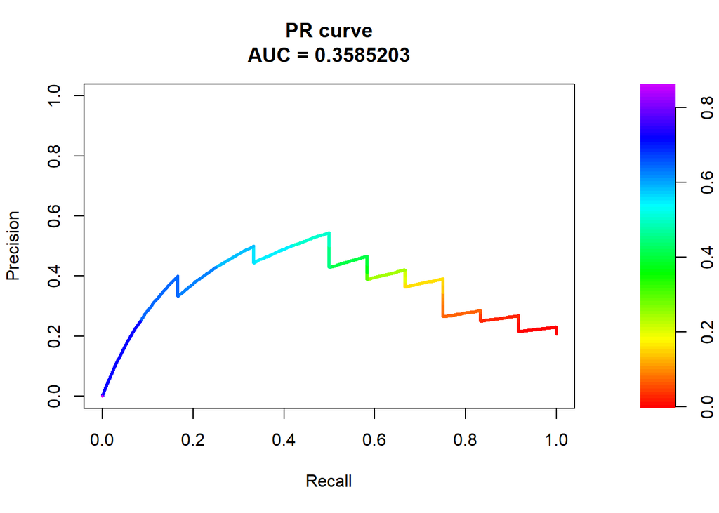

```
##          Accuracy   ROC    PR Precision Recall Sensitivity Specificity    F1
## Accuracy     0.81 0.725 0.359     0.545    0.5         0.5       0.891 0.522
##          Balanced.Accuracy
## Accuracy             0.696
```

Plot the logit.

```
## [1] "Probability predicted by the LR using PRQ data vs true Working"
```

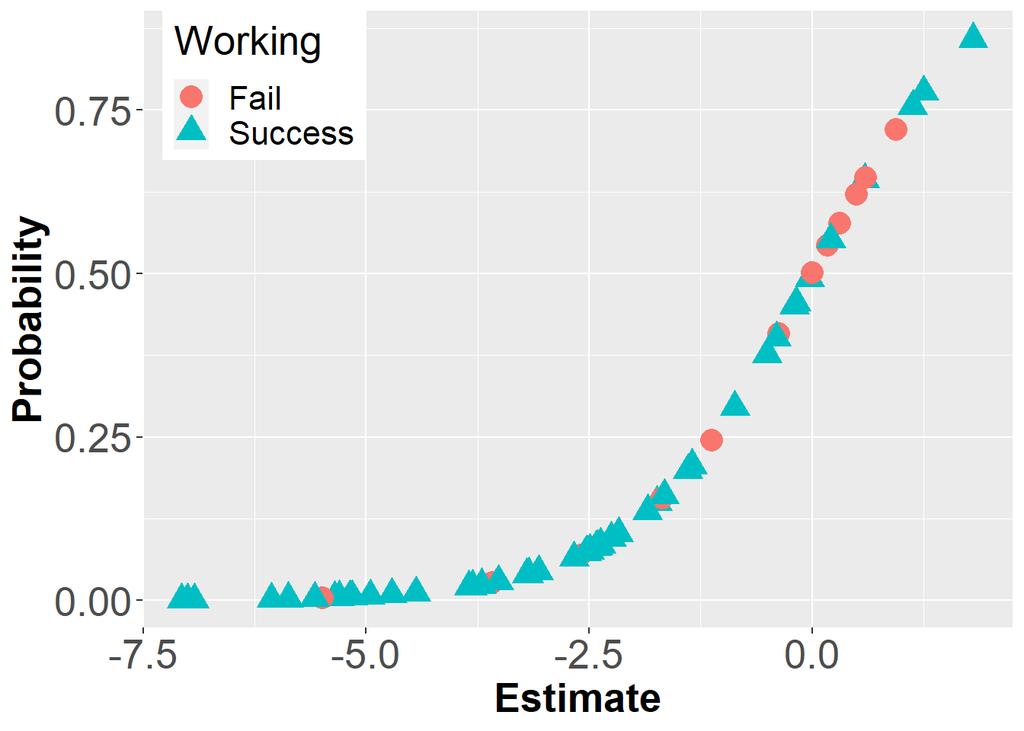

```
## [1] "Probability predicted by the LR using PRQ data vs true Status"
```

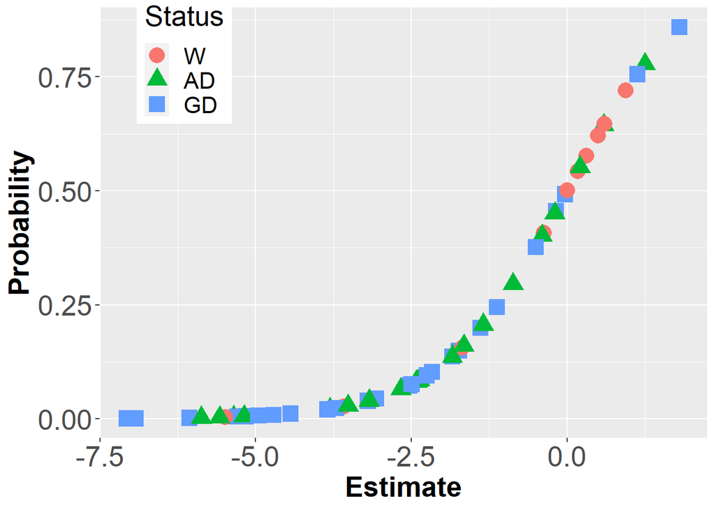

```
## [1] "Estimate and Probabilities per working outcome status"
```

```
## # A tibble: 3 × 3
##   Status  Mean    SD
##   <fct>  <dbl> <dbl>
## 1 W      -1.02  2.07
## 2 AD     -2.33  2.11
## 3 GD     -3.01  2.41
```

```
## # A tibble: 3 × 3
##   Status  Mean    SD
##   <fct>  <dbl> <dbl>
## 1 W      0.389 0.272
## 2 AD     0.202 0.238
## 3 GD     0.158 0.233
```

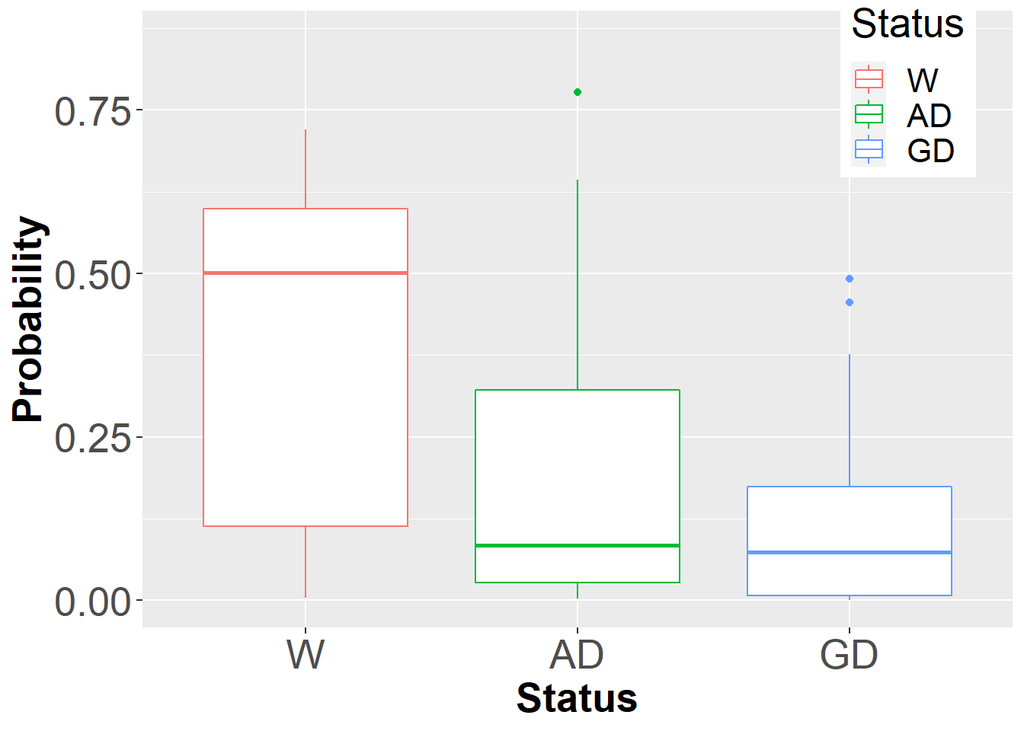

```
##
##  Kruskal-Wallis rank sum test
##
## data:  Probability by Status
## Kruskal-Wallis chi-squared = 5.9027, df = 2, p-value = 0.05227
```

```
##
##  Pairwise comparisons using Wilcoxon rank sum exact test
##
## data:  df_perf$Probability and df_perf$Status
##
##    W     AD
## AD 0.095 -
## GD 0.019 0.342
##
## P value adjustment method: none
```

Names of the dogs that were false positives and false negatives.

```
## [1] "FALSE POSITIVE dogs predicted to fail, but succeed"
```

```
## [1] Illana  Harmony Josie   Ebbi    Eddie
## 101 Levels: Clay Diva Dora Douglas Dugg Earl Ebbi Eddie Edrick Effie ... Zodiac
```

```
## [1] "FALSE NEGATIVE dogs predicted to succeed, but failed"
```

```
## [1] Hayley  Douglas Emmy    Zac     Herbie  Zeb
## 101 Levels: Clay Diva Dora Douglas Dugg Earl Ebbi Eddie Edrick Effie ... Zodiac
```

## 3.2 Interpretation

Discuss model interpretation.

```
##                                  Estimate     P-value         OR      2.5 %
## (Intercept)                    -2.3985903 0.000360435 0.09084593 0.01777559
## S.Crate.Stimulus_mean           1.2842290 0.013879653 3.61188200 1.43188979
## S.Crate.Handler_mean           -1.0871703 0.055885639 0.33716923 0.09451954
## S.Familiarisation.Handler_mean  0.5995911 0.083700609 1.82137392 0.92869587
## Walking.Initiative              0.5227640 0.246357240 1.68668317 0.70169629
## S.Distractions.Difference_mean  0.4845349 0.271296409 1.62341971 0.69834313
## S.Distractions.Pull_mean       -0.4171359 0.354936682 0.65893140 0.25529337
##                                    97.5 %
## (Intercept)                     0.2697949
## S.Crate.Stimulus_mean          11.9015824
## S.Crate.Handler_mean            0.9307685
## S.Familiarisation.Handler_mean  3.8833344
## Walking.Initiative              4.3927580
## S.Distractions.Difference_mean  4.1102681
## S.Distractions.Pull_mean        1.5915120
```

# 4 Conclusion